# NumPy Toolbox

EE1021 Programming for Engineers - Lecture 11

Basri Erdogan

## Lecture Goals

1. Explain what **NumPy** is and how its fixed-size, homogeneous **arrays** differ from Python lists
2. Create arrays with `np.array`, `arange`, `linspace`, `zeros`, `ones`, `eye`, `meshgrid`, and `np.random`
3. Inspect array **attributes** (`ndim`, `shape`, `dtype`) and change layout with `reshape` and `.T`
4. Select data with **indexing and slicing**, including **logical (boolean)** and **fancy** indexing
5. Compute with **elementwise arithmetic**, comparisons, **reductions** (`sum`, `min`, `mean`), sorting, and stacking
6. Use arrays as **matrices**: `@` matrix product and `np.linalg` (`solve`, `inv`, `det`, `matrix_rank`)

## Last Time

- File input/output
  - Opening, reading, and writing text files
  - The `with` statement
  - CSV files and the `csv` module

## Today

- The NumPy module
  - Arrays: creation, attributes, reshaping
  - Indexing and slicing
  - Elementwise operations and reductions
  - Matrices and linear algebra

# Part 1: What Is NumPy?

## NumPy

- NumPy is the fundamental package for **scientific computing** in Python.
- It is a Python library that provides:
  - A **multidimensional array** object
  - Various derived objects, such as masked arrays and matrices
  - Routines for **fast operations** on arrays
    - mathematical, logical, shape manipulation, sorting, selecting, I/O, discrete Fourier transforms, basic linear algebra, basic statistics, random simulation, and much more

[figure not shown]

- Official site and documentation: https://numpy.org/

## NumPy Arrays vs. Python Lists

- NumPy arrays have a **fixed size** at creation, unlike Python lists (which can grow dynamically).
- The elements are all required to be of the **same data type**, and thus the same size in memory (exception: `object` arrays).
- NumPy arrays enable advanced mathematical operations on **large amounts of data** with less code.
- Most of today’s scientific and mathematical Python software builds on NumPy arrays.

## Vectorization and Broadcasting

- **Vectorization**: no explicit loops or indexing in *your* code — the looping happens behind the scenes in optimized, pre-compiled C code.
  - Vectorized code is more concise and easier to read
  - Fewer lines of code generally means fewer bugs
  - The code closely resembles standard mathematical notation
- **Broadcasting**: operations act **element by element** implicitly — not just arithmetic, but logical, bit-wise, and functional operations too.
  - Works between arrays of the same shape, a scalar and an array, or even arrays of different shapes, provided the smaller one is “expandable” to the larger shape unambiguously.

## Using a Function from a Module (Recap)

- Method 1 — import all and use the name:
  - `from moduleX import *` then `function_name(...)`
- Method 2 — dot notation:
  - `import moduleX` then `moduleX.function_name(...)`
- Method 3 — alias and dot notation:
  - `import moduleX as mn` then `mn.function_name(...)`
- Method 4 — import only the function itself:
  - `from moduleX import function_name` then `function_name(...)`

## Importing NumPy

By convention, NumPy is imported with the alias `np`:

```python
import numpy as np
```

# Part 2: Creating Arrays

## NumPy’s Main Object Is the Array

- NumPy’s main object is the **homogeneous multidimensional array** (`ndarray`).
- *Homogeneous*: all elements have the same type.
- In NumPy, dimensions are called **axes**; the number of axes is the **rank**.
  - A vector is an array of rank 1
  - A 2-D matrix is an array of rank 2

## The Array Object — Creation

```python
>>> import numpy as np
>>> a = np.array([0, 1, 2])                  # 1-d array
>>> a
array([0, 1, 2])
>>> b = np.array([[0, 1, 2], [3, 4, 5]])     # 2 x 3 array
>>> b
array([[0, 1, 2],
       [3, 4, 5]])
```

- Pass a list (or nested lists) to `np.array`; the nesting depth sets the rank.

## Array Attributes

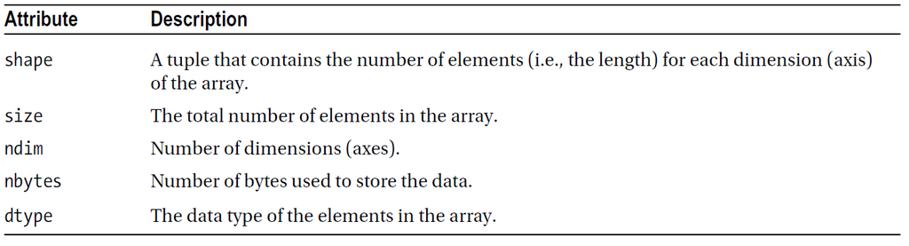

## Array Attributes

```python
>>> b = np.array([[0, 1, 2], [3, 4, 5]])   # 2 x 3 array
>>> b.ndim        # number of dimensions
2
>>> b.shape       # dimension sizes
(2, 3)
>>> len(b)        # size of the first dimension
2
>>> b.T           # transpose
array([[0, 3],
       [1, 4],
       [2, 5]])
```

## Arrays: Numerical Data Types

- Remember: NumPy arrays are **homogeneous**!

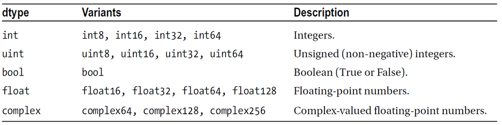

## Creating an Array of a Specific Type

```python
>>> a = np.array(range(10), float)
>>> a
array([ 0., 1., 2., 3., 4., 5., 6., 7., 8., 9.])
>>> a.dtype
dtype('float64')
```

- The second argument (or the `dtype=` keyword) sets the element type.

## Creating Arrays

Four general mechanisms for creating arrays:

1. **Conversion** from other Python structures (e.g., lists, tuples)
2. **Intrinsic** NumPy creation functions (e.g., `arange`, `ones`, `zeros`)
3. **Reading** arrays from disk, in standard or custom formats
4. **Special library functions** (e.g., `np.random`)

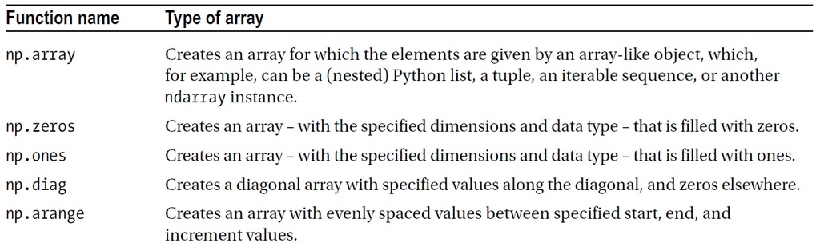

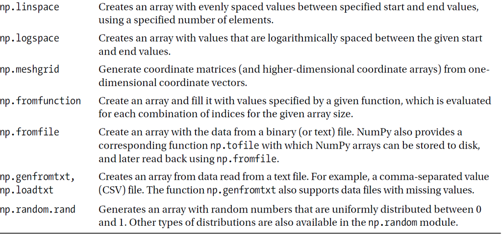

## Creating an Array of Zeros or Ones

```python
>>> np.zeros(7, dtype=int)
array([0, 0, 0, 0, 0, 0, 0])
>>> np.ones((2, 3), dtype=float)
array([[ 1., 1., 1.],
       [ 1., 1., 1.]])
```

- Pass a shape tuple for multidimensional arrays.

## Creating Arrays Containing Number Sequences

```python
>>> np.arange(10)
array([0, 1, 2, 3, 4, 5, 6, 7, 8, 9])
>>> np.arange(2, 7)
array([2, 3, 4, 5, 6])
>>> np.arange(2, 7, 2)      # start, end (exclusive), step
array([2, 4, 6])
```

- Like `range` in Python, but returns a NumPy array object.

## Creating Arrays Containing Number Sequences

```python
>>> print(np.arange(1, 5.5, 0.5))       # start, end (exclusive), step
[ 1.  1.5 2.  2.5 3.  3.5 4.  4.5 5. ]
>>> print(np.arange(1, 5.5, 0.5)[3:1:-1])   # slicing works like lists
[ 2.5 2. ]
>>> print(np.linspace(1, 5, 9))         # start, end, number of points
[ 1.  1.5 2.  2.5 3.  3.5 4.  4.5 5. ]
>>> print(np.random.rand(5))            # random values between 0 and 1
[ 0.53844313 0.3384871  0.5763536  0.29159273 0.43938366]
```

- More creation routines: https://numpy.org/doc/stable/reference/routines.array-creation.html

## Mesh-Grid Arrays

```python
>>> x = np.array([-1, 0, 1])
>>> y = np.array([-2, 0, 2])
>>> X, Y = np.meshgrid(x, y)
>>> X
array([[-1, 0, 1],
       [-1, 0, 1],
       [-1, 0, 1]])
>>> Y
array([[-2, -2, -2],
       [ 0,  0,  0],
       [ 2,  2,  2]])
```

## Mesh-Grid Arrays

- A common usage: evaluating a function over **two variables** `x` and `y` — for example when plotting surfaces.
- Example: calculate `z = (x + y)**2` at all combinations of `x` and `y`:

```python
>>> Z = (X + Y)**2
>>> Z
array([[9, 4, 1],
       [1, 0, 1],
       [1, 4, 9]])
```

## Creating Matrix Arrays

```python
>>> np.identity(4)
array([[ 1., 0., 0., 0.],
       [ 0., 1., 0., 0.],
       [ 0., 0., 1., 0.],
       [ 0., 0., 0., 1.]])
>>> np.eye(3)
array([[ 1., 0., 0.],
       [ 0., 1., 0.],
       [ 0., 0., 1.]])
```

## Reshaping an Array

```python
>>> a = np.array(range(10), float)
>>> a
array([ 0., 1., 2., 3., 4., 5., 6., 7., 8., 9.])
>>> a = a.reshape((5, 2))
>>> a
array([[ 0., 1.],
       [ 2., 3.],
       [ 4., 5.],
       [ 6., 7.],
       [ 8., 9.]])
>>> a.shape
(5, 2)
```

- The total number of elements must stay the same.

# Part 3: Indexing and Slicing

## Indexing and Slicing: Similar to Lists

```python
>>> a = np.diag(np.arange(3))
>>> a
array([[0, 0, 0],
       [0, 1, 0],
       [0, 0, 2]])
>>> a[1, 1]
1
>>> a[2, 1] = 0        # assignment works elementwise
>>> a[1]               # a[1, :] also works
array([0, 1, 0])
>>> a[:, 1]
array([0, 1, 0])
>>> a[2][1:]
array([0, 2])
```

- Slicing: specify which rows/columns to take with `A[rows, columns]`.

## Indexing and Slicing: Matrices

| 0 | 1 | 2 | 3 | 4 | 5 |
| --- | --- | --- | --- | --- | --- |
| 10 | 11 | 12 | 13 | 14 | 15 |
| 20 | 21 | 22 | 23 | 24 | 25 |
| 30 | 31 | 32 | 33 | 34 | 35 |
| 40 | 41 | 42 | 43 | 44 | 45 |
| 50 | 51 | 52 | 53 | 54 | 55 |

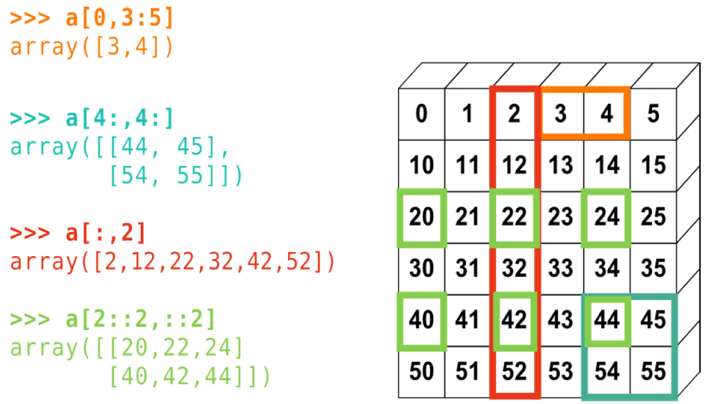

## Logical Indexing

```python
>>> a = np.random.randint(0, 21, 15)    # 15 ints in [0, 20]
>>> a
array([10, 3, 8, 0, 19, 10, 11, 9, 10, 6, 0, 20, 12, 7, 14])
>>> (a % 3 == 0)
array([False,  True, False,  True, False, False, False,  True,
       False,  True,  True, False,  True, False, False])
```

- What will be the result?
- What will be the type of the new object?

## Logical Indexing

```python
>>> mask = (a % 3 == 0)
>>> extract_from_a = a[mask]    # extract sub-array: this is a copy!
>>> extract_from_a
array([ 3, 0, 9, 6, 0, 12])
>>> a[mask] = -1                # change the selected elements
>>> a
array([10, -1, 8, -1, 19, 10, 11, -1, 10, -1, -1, 20, -1, 7, 14])
```

## Fancy Indexing

```python
# Indexing with an array/list of integers
>>> a = np.arange(0, 100, 10)
>>> a[[2, 3, 2, 4, 2]]          # note: [2, 3, 2, 4, 2] is a Python list
array([20, 30, 20, 40, 20])
```

- Indices may repeat and appear in any order.

# Part 4: Operations on Arrays

## Elementwise Operations

```python
>>> arr = np.array([0, 1.5, -1.5, 2])
>>> arr + 1                      # elementwise arithmetic
array([ 1. , 2.5, -0.5, 3. ])
>>> abs(arr) == 1.5              # elementwise comparison
array([False,  True,  True, False])
```

## Array Arithmetic

Arithmetic operators on arrays apply **elementwise**. A new array is created and filled with the result.

```python
>>> x = np.array([1, 5, 2])
>>> y = np.array([7, 4, 1])
>>> x + y
array([8, 9, 3])
>>> x * y     # elementwise! Use np.dot(x, y) or x @ y for the dot product.
array([ 7, 20, 2])
>>> x - y
array([-6, 1, 1])
>>> x // y
array([0, 1, 2])
>>> x % y
array([1, 1, 0])
```

- Note that here `x` and `y` have the same size.

## Comparisons and Boolean Operations

```python
>>> a = np.random.randint(0, 11, 15)   # 15 ints in [0, 10]
>>> a
array([ 4, 9, 1, 7, 0, 9, 8, 10, 1, 0, 7, 7, 9, 5, 1])
```

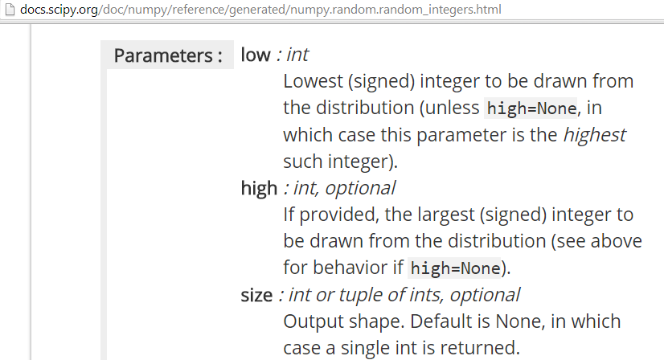

## Comparisons and Boolean Operations

```python
>>> a = np.random.randint(0, 11, 15)
>>> b = np.random.randint(0, 11, 15)
>>> comp1 = (a == b)
>>> comp1
array([False, False, False, False, False,  True, False, False,
       False, False, False, False, False, False, False])
>>> comp1.any()      # is any element True?
True
>>> comp1.all()      # are all elements True?
False
>>> comp1.nonzero()  # get the True indices
(array([5]),)
```

## Reductions

```python
>>> x = np.array([[1, 1], [2, 2]])
>>> x
array([[1, 1],
       [2, 2]])
>>> x.sum()             # works on the entire matrix
6
>>> x.sum(axis=0)       # sum over the columns (first dimension)
array([3, 3])
>>> x[:, 0].sum(), x[:, 1].sum()
(3, 3)
>>> x.sum(axis=1)       # sum over the rows (second dimension)
array([2, 4])
```

- Also works with `x.min`, `x.max`, `x.mean`, etc.

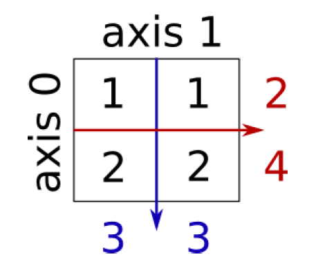

## Sorting Along an Axis

```python
>>> a = np.array([[4, 3, 5], [1, 2, 1]])
>>> b = np.sort(a, axis=1)      # returns a sorted copy
>>> b
array([[3, 4, 5],
       [1, 1, 2]])
```

```python
>>> a.sort(axis=1)              # sorts in place
>>> a
array([[3, 4, 5],
       [1, 1, 2]])
```

## Array Stacking

Concatenate two arrays vertically (`vstack`) or horizontally (`hstack`):

```python
>>> a = np.array((1, 2, 3))
>>> b = np.array((2, 3, 4))
>>> np.hstack((a, b))
array([1, 2, 3, 2, 3, 4])
>>> a = np.array([[1], [2], [3]])
>>> b = np.array([[2], [3], [4]])
>>> np.hstack((a, b))
array([[1, 2],
       [2, 3],
       [3, 4]])
```

## Array Stacking

```python
>>> a = np.array([1, 2, 3])
>>> b = np.array([2, 3, 4])
>>> np.vstack((a, b))
array([[1, 2, 3],
       [2, 3, 4]])
>>> a = np.array([[1], [2], [3]])
>>> b = np.array([[2], [3], [4]])
>>> np.vstack((a, b))
array([[1],
       [2],
       [3],
       [2],
       [3],
       [4]])
```

# Part 5: Matrices and Linear Algebra

## Matrix Basics (NumPy)

- A matrix is a 2-D NumPy array: shape `(m, n)`.
- Transpose: `A.T` — identity: `np.eye(n)`.
- **Elementwise vs. matrix operations:**
  - Elementwise: `A * B` (same shape)
  - Matrix multiply: `A @ B` or `np.matmul(A, B)`
- Shape rule for `@`: `(m x k) @ (k x n) -> (m x n)`

## Matrix Basics (NumPy)

```python
import numpy as np

A = np.array([[1, 2],
              [3, 4]])      # 2 x 2
B = np.array([[0, 1],
              [1, 0]])      # 2 x 2

A_T = A.T                   # transpose
I2  = np.eye(2)             # identity
E   = A * B                 # elementwise product
P   = A @ B                 # matrix product
```

## Core Linear Algebra Operations

- Solve `Ax = b`: `np.linalg.solve(A, b)` — prefer over forming `A**-1`
- Inverse (square, well-conditioned): `np.linalg.inv(A)`
- Determinant / rank: `np.linalg.det(A)`, `np.linalg.matrix_rank(A)`
- Other: `np.linalg.norm(A)`, `np.linalg.svd(A)`, `np.linalg.eig(A)`

**Tip**

For stability and speed, prefer `solve` over inverse-then-multiply.

## Core Linear Algebra Operations

```python
import numpy as np

A = np.array([[3., 2.],
              [1., 2.]])    # det = 4
b = np.array([7., 5.])

x     = np.linalg.solve(A, b)      # solution to Ax = b
detA  = np.linalg.det(A)
rank  = np.linalg.matrix_rank(A)
invA  = np.linalg.inv(A)           # avoid in pipelines
```

## Summary

- NumPy arrays are **homogeneous** and **fixed-size**; vectorized operations replace explicit loops.
- Create arrays with `np.array`, `arange`, `linspace`, `zeros`/`ones`, `eye`, `meshgrid`, and `np.random.randint`/`rand`.
- Inspect with `ndim`, `shape`, `dtype`; reorganize with `reshape` and `.T`.
- Index like lists, plus **logical masks** and **fancy indexing**.
- Reductions (`sum`, `min`, `mean`) take an `axis` argument; `sort`, `hstack`, `vstack` reorganize data.
- For matrices: `@` for products and `np.linalg` for `solve`, `inv`, `det`, `rank`.